# Phenols and Phthalates dimension reduction

Guannan Shen

September 4, 2019

```
## [1] "/home/guanshim/Documents/gitlab/ECCHO_github/DataProcessed/more_chems"
```

# 1 Preprocessing

## 1.1 Import data and Features

$$N = 407$$
for both of phthalates and phenols.
There are 17 chemicals: 8 phenols and 9 phthalates.
Anne have scaled all of the variables by creatinine concentration and also removed the chemicals that were reported as <75% detectable in the reports from the CDC lab that conducted the analyses (see attached).
DEHP (detection limits) consists of Mono-2-ethylhexyl phthalate (MEHP) (0.5), Mono-(2-ethyl-5-hydroxyhexyl) phthalate (MEHHP) (0.2), Mono-(2-ethyl-5-oxohexyl) phthalate (MEOHP) (0.2), Mono-(2-ethyl-5-carboxylpentyl) phthalate (MECPP) (0.2).

```r
dir = "~/Documents/gitlab/ECCHO_github/"
## reference plots
source(paste0(dir, "Code/more_chems/ref_plots.R"))
source(paste0(dir, "Code/more_chems/sum_tables.R"))
source(paste0(dir, "Code/more_chems/Dimen_reduc_clustering.R"))
## import data
phthal_di2 <- read.csv(paste0(dir, "DataRaw/more_chems/phthal_di2_aug2019.csv"),
    header = TRUE)
#
dim(phthal_di2)
```

```
## [1] 407  34
```

```r
neonatal_clin <- phthal_di2[, 1:17]
# two chemicals
phthalates <- phthal_di2[, c(1, 18:26)]
head(phthalates)
```

```
##     pid MHiBP_ug_g_creat MBP_ug_g_creat MBzP2_ug_g_creat MCNP_ug_g_creat
## 1 10611         2.895996      17.753714       49.9874087       8.5620750
## 2 10645         2.460457      10.896309        5.9753954       2.4604569
## 3 10652         2.180006       6.072874        1.7128620       3.8928683
## 4 10654         1.203852       1.605136        0.8025682       0.8025682
## 5 10661        14.555682      18.700350        2.9111363       1.4802388
## 6 10662         1.641414       5.681818        3.4090909       3.6616162
##   MCOP_ug_g_creat MCPP_ug_g_creat MEP2_ug_g_creat MIBP_ug_g_creat
## 1      163.686729      10.1989423        25.68623        6.547469
## 2       21.441125       3.1634446        11.95079        3.866432
## 3       24.914357       2.0242915        54.81159        5.294301
## 4        4.815409       0.4012841        60.59390        2.006421
## 5        4.243351       0.3453891        80.42631       37.104653
## 6       23.611111       1.5151515        68.30808        3.030303
##   DEHP_sum_nmol_g_creat
## 1             242.55143
## 2              73.12180
## 3              92.23185
## 4              21.36312
## 5             107.78704
## 6              58.28898
```

```r
phenols <- phthal_di2[, c(1, 27:34)]
head(phenols)
```

```
##     pid X_24_DCP_ug_g_creat X_25_DCP_ug_g_creat M_PB_ug_g_creat
## 1 10611          59.6826996        3857.5925460       203.60111
## 2 10645           0.7029877           0.7029877       301.58172
## 3 10652           0.6228589           2.8028652        19.77577
## 4 10654           2.4077047          16.8539326        24.47833
## 5 10661           0.6414368          17.4174767       103.12330
## 6 10662           0.2525253           5.3030303       217.04545
##   P_PB_ug_g_creat BP_3_ug_g_creat BPA_ug_g_creat BPS_ug_g_creat
## 1      106.774112      590.027701      1.2591287     0.37773860
## 2       87.521968     2182.425308      0.7029877     0.35149385
## 3        8.097166        9.810028      2.0242915     0.31142946
## 4        4.414125      258.025682      0.4012841     0.40128411
## 5       19.687176       21.216756      3.1578428     0.09868259
## 6       65.656566      250.252525      1.2626263     0.88383838
##   TCS_ug_g_creat
## 1     127.549736
## 2      55.184534
## 3      20.554344
## 4     347.110754
## 5      10.065624
## 6       6.060606
```

```r
## all together
chems <- merge(phthalates, phenols, by = "pid") %>% column_to_rownames("pid")

############## save chems ########
write.csv(chems, "~/Documents/gitlab/ECCHO_github/DataProcessed/more_chems/chems_adjusted.csv",
    row.names = TRUE)
```

## 1.2 Highly skewed data

log transformation?

```r
#
print("There is no 0 in the data.")
```

```
## [1] "There is no 0 in the data."
```

```r
sum(chems == 0)
```

```
## [1] 0
```

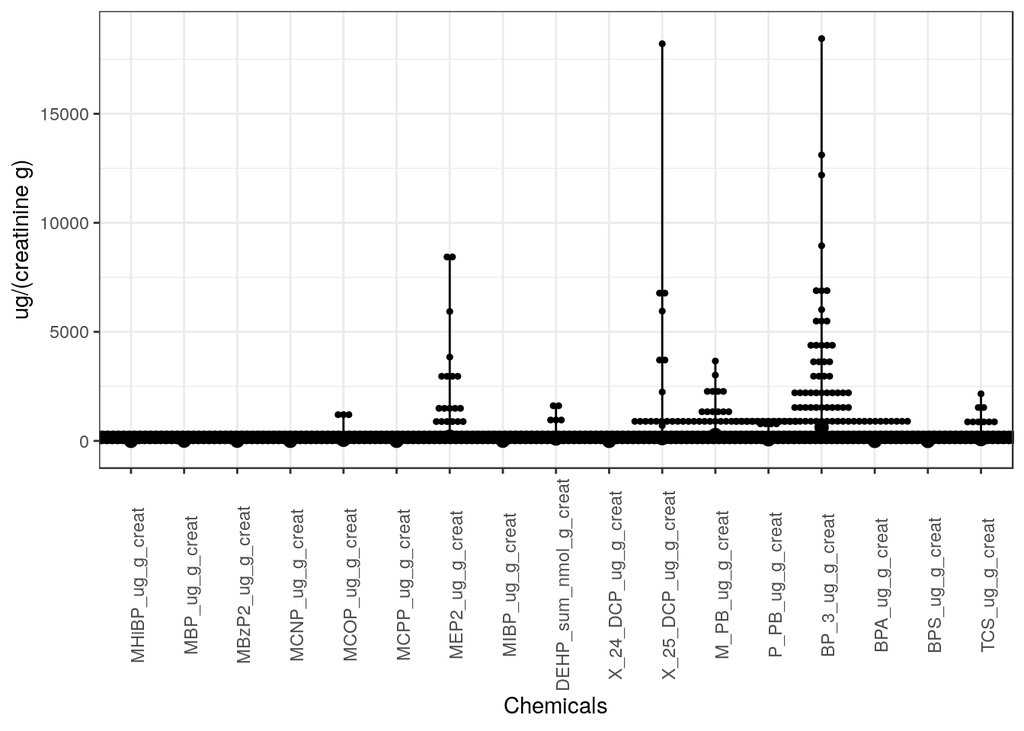

```r
######## right skewed raw data ######
test <- chems %>% stack()
dot_groupby(test, test$values, test$ind, 0.4, "Chemicals", "ug/(creatinine g)")
```

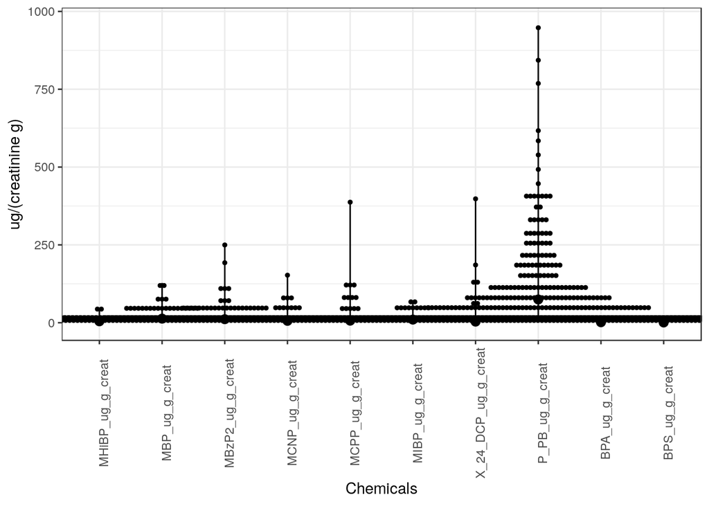

```r
# select if
test <- chems %>% select_if(~max(., na.rm = TRUE) < 1000) %>%
    stack()
dot_groupby(test, test$values, test$ind, 0.4, "Chemicals", "ug/(creatinine g)")
```

```r
# max < 150
test <- chems %>% select_if(~max(., na.rm = TRUE) < 150) %>%
    stack()
density_values_group(test, "max < 150")
```

```
## [1] "A column called group and a column called values"
```

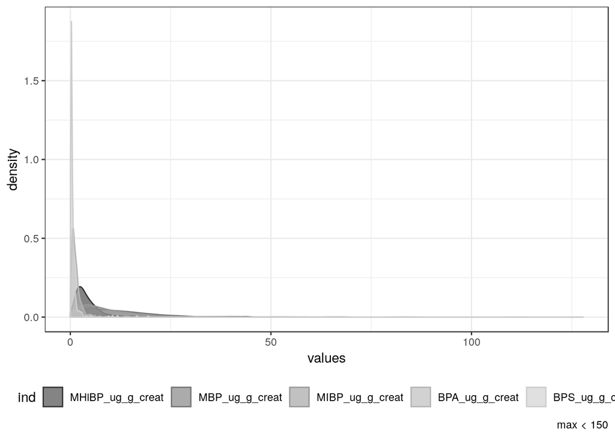

```r
######## the detection limits applied to non creatinine adjusted
######## data ######### detection limits #######
dect_lim <- c(0.4, 0.4, 0.3, 0.2, 0.2, 0.2, 0.6, 0.2, 0.2, 0.1,
    0.1, 1, 0.1, 0.2, 0.1, 0.1, 1)
names(dect_lim) <- colnames(chems)
# lower_counts <- sapply(colnames(chems), function(x){
# sum(chems[, x] < dect_lim[x]) }) # summary tables sum_chems
# <- cbind(lower_counts, dect_lim, sum_table(chems))
# sum_chems %>% kable

########## natural log transformation ########
chems_log <- log(chems, base = exp(1))
density_values_group(chems_log %>% stack(), "8 phenols and 9 phthalates: log transformed")
```

```
## [1] "A column called group and a column called values"
```

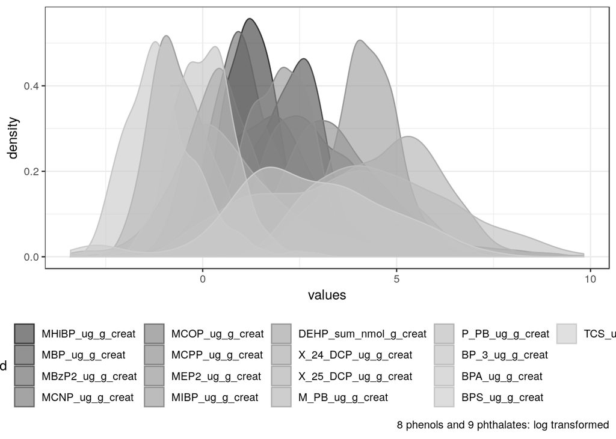

```r
# log transformation of two chemical groups
phthalates_log <- log(phthalates %>% column_to_rownames("pid"),
    base = exp(1))
phenols_log <- log(phenols %>% column_to_rownames("pid"), base = exp(1))
density_values_group(phthalates_log %>% stack(), "9 phthalates: log transformed")
```

```
## [1] "A column called group and a column called values"
```

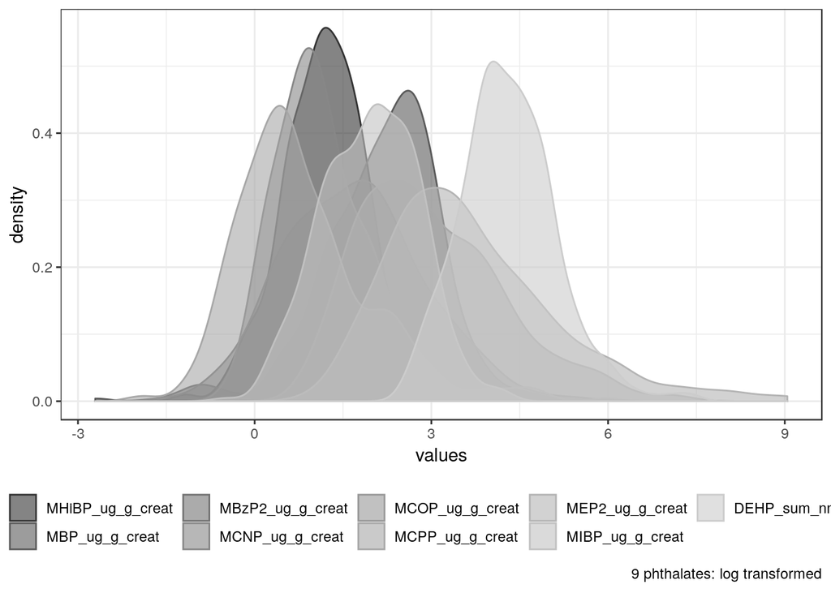

```r
density_values_group(phenols_log %>% stack(), "8 phenols: log transformed")
```

```
## [1] "A column called group and a column called values"
```

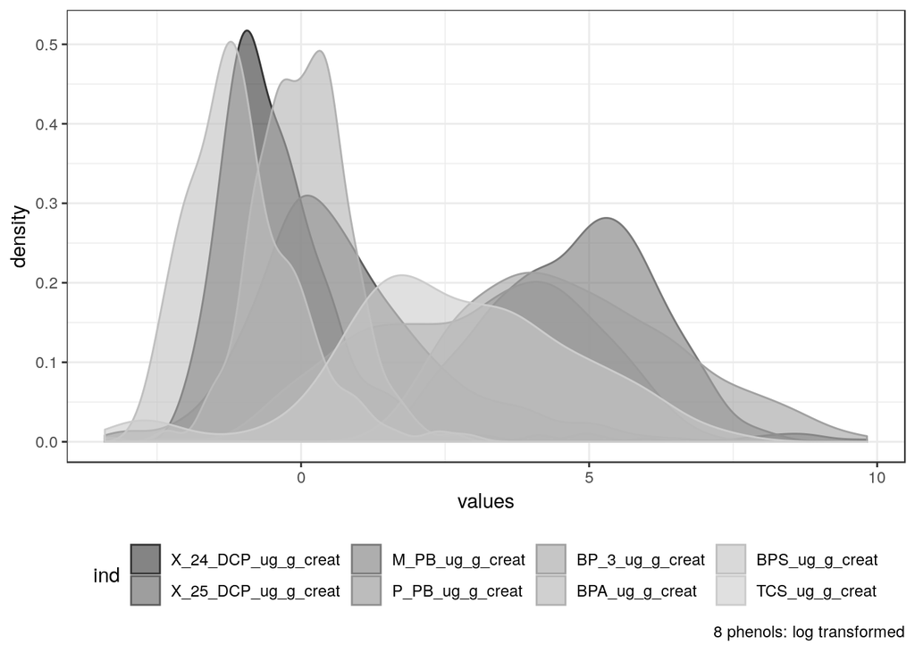

```r
### z-score standardization methods, but the rescale does not
### change the Pearson correlation ###
source(paste0(dir, "Code/more_chems/Dimen_reduc_clustering.R"))
density_values_group(chems_log %>% rescale0_1() %>% as.data.frame() %>%
    stack(), "8 phenols and 9 phthalates: log transformed and standardized")
```

```
## [1] "A column called group and a column called values"
```

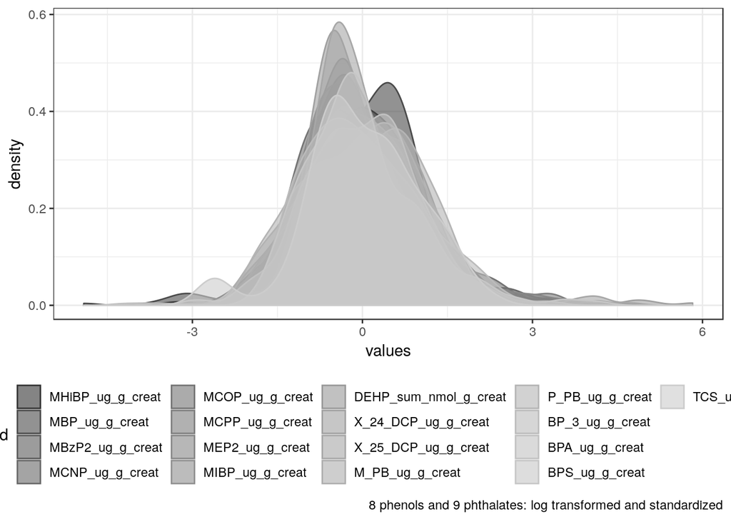

```r
################### save the detection limits, chems and chems_log datafile
################### ###########

write.csv(chems_log, "~/Documents/gitlab/ECCHO_github/DataProcessed/more_chems/chems_adjusted_log.csv",
    row.names = TRUE)

write.csv(dect_lim, "~/Documents/gitlab/ECCHO_github/DataProcessed/more_chems/dect_lim.csv",
    row.names = TRUE)
```

## 1.3 Missing Values (Below the limit of detection)

## 1.4 explore correlations

```
## [1] "Use pairwise.complete.obs, and methods from pearson, kendall, spearman"
```

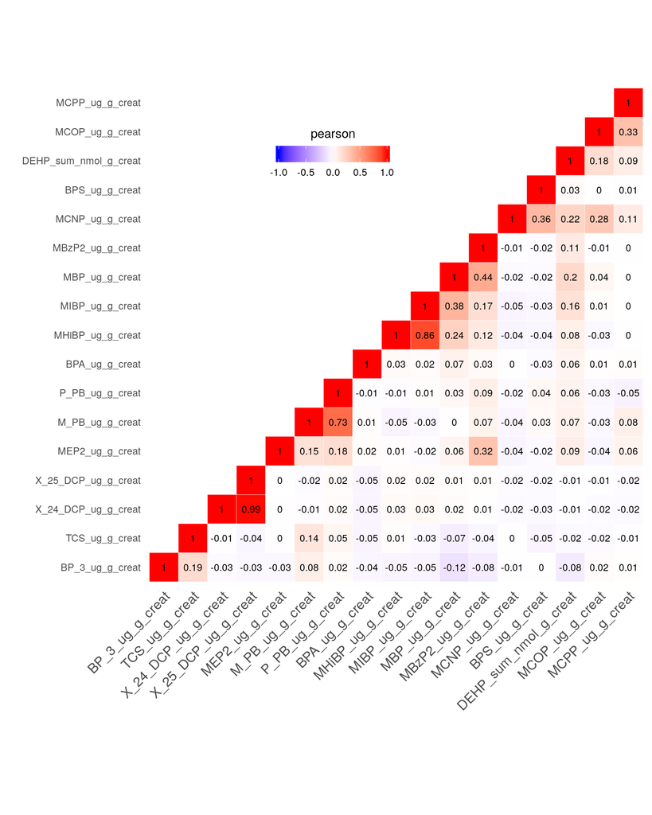

```r
# correlation heatmap
source(paste0(dir, "Code/more_chems/ref_plots.R"))
# cor_heatmap <- function(df, method, reorder, hclust_method,
# text_size)
chems_pearson <- cor_heatmap(chems %>% rescale0_1(), "pearson",
    TRUE, "complete", text_size = 3)
```

```
## [1] "Use pairwise.complete.obs, and methods from pearson, kendall, spearman"
```

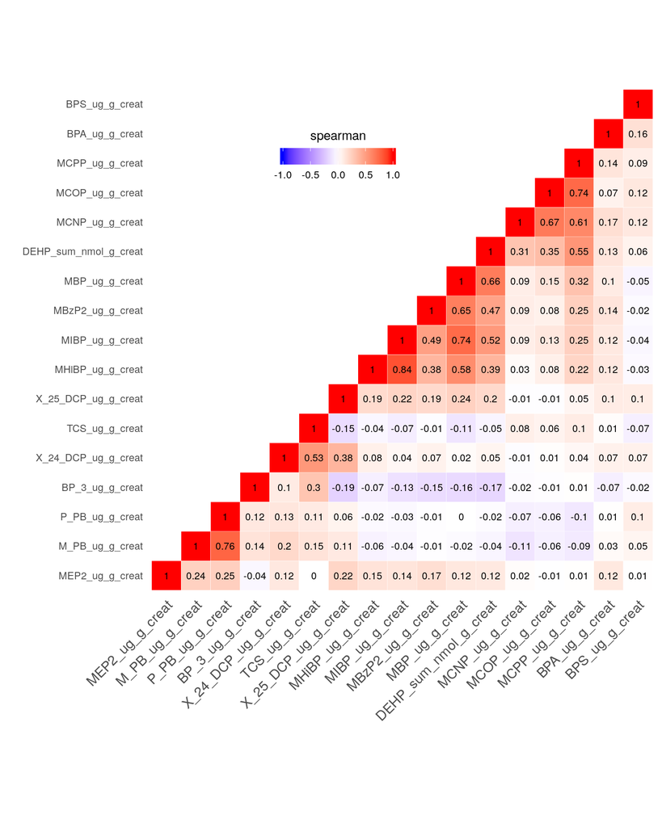

```r
# robust for outliers, rank-based correlation, log
# transformation won't change the correlation heatmap
chems_spearman <- cor_heatmap(chems %>% rescale0_1(), "spearman",
    TRUE, "complete", text_size = 3)
```

```
## [1] "Use pairwise.complete.obs, and methods from pearson, kendall, spearman"
```

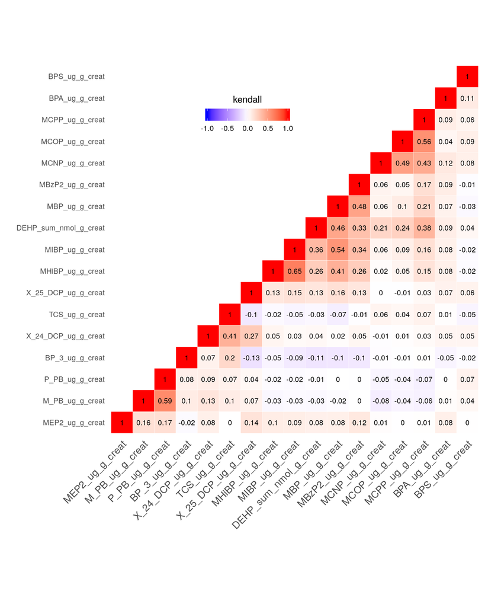

```r
chems_kendall <- cor_heatmap(chems %>% rescale0_1(), "kendall",
    TRUE, "complete", text_size = 3)
```

```
## [1] "Use pairwise.complete.obs, and methods from pearson, kendall, spearman"
```

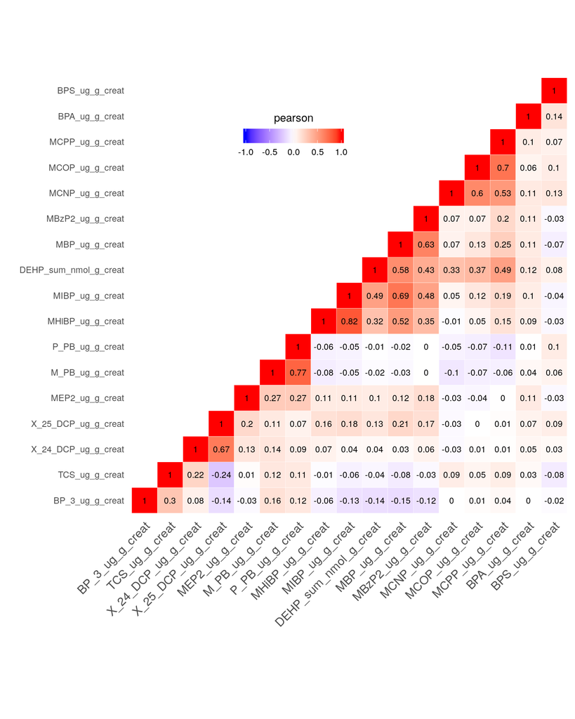

```r
##### log transformed #####
chems_log_pearson <- cor_heatmap(chems_log %>% rescale0_1(),
    "pearson", TRUE, "complete", text_size = 3)
```

```
## [1] "Use pairwise.complete.obs, and methods from pearson, kendall, spearman"
```

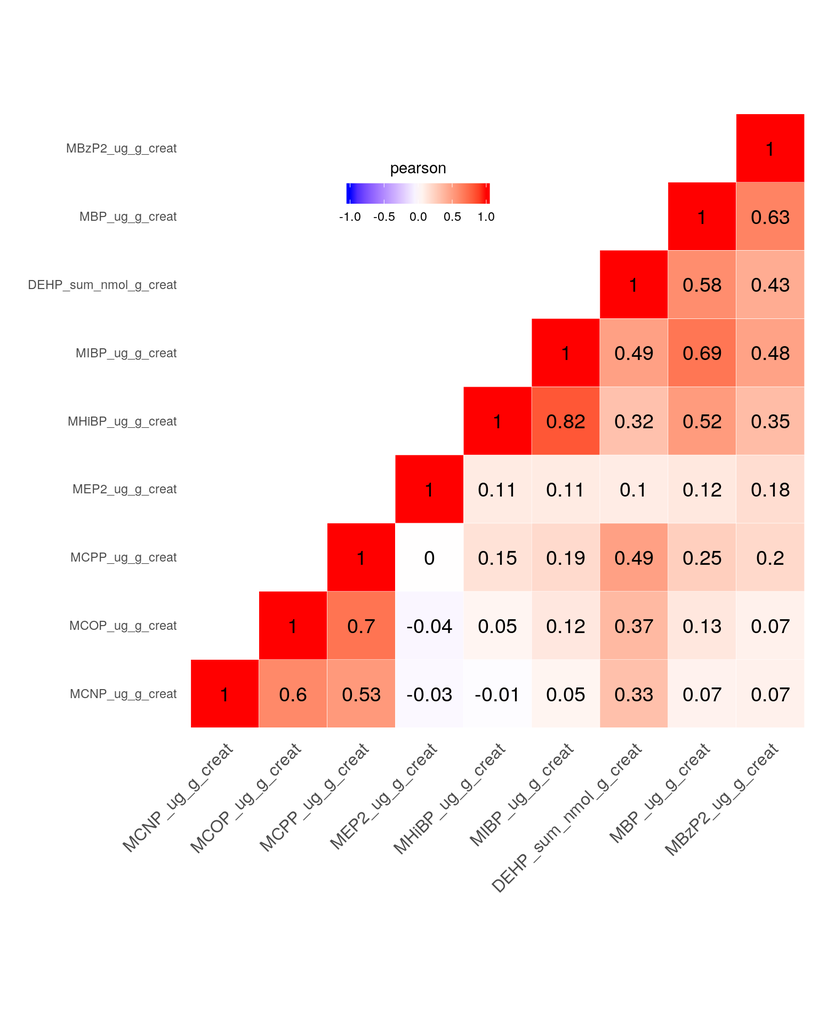

```r
phthalates_log_pearson <- cor_heatmap(phthalates_log %>% rescale0_1(),
    "pearson", TRUE, "complete", text_size = 5)
```

```
## [1] "Use pairwise.complete.obs, and methods from pearson, kendall, spearman"
```

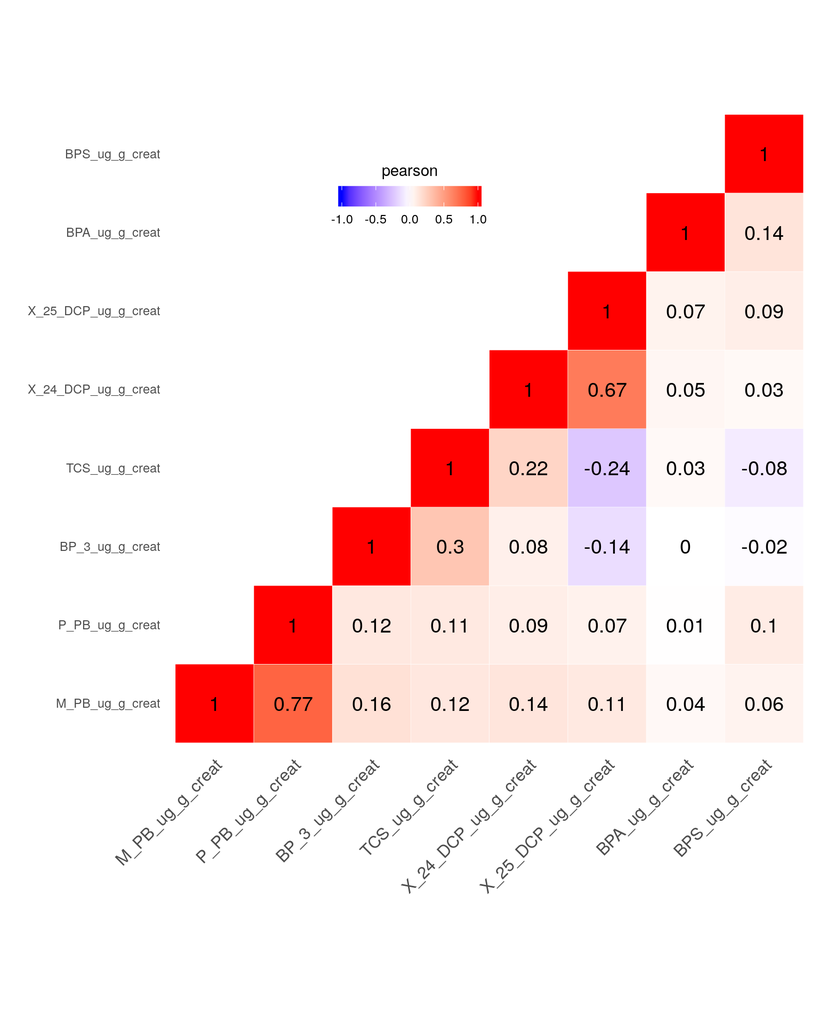

```r
phenols_log_pearson <- cor_heatmap(phenols_log %>% rescale0_1(),
    "pearson", TRUE, "complete", text_size = 5)
```

# 2 Dimension Reduction and/or feature Agglomeration

Feature agglomeration (clustering): This is a “bottom-up” approach, each feature starts in its own cluster, and pairs of clusters are merged as one moves up the hierarchy.  
Dimension reduction: PCA, factor analysis.

## 2.1 hierarchical clustering of features

In complete-link clustering or complete-linkage clustering , the similarity of two clusters is the similarity of their most dissimilar members. This complete-link merge criterion is non-local; the entire structure of the clustering can influence merge decisions.  
In single-link clustering or single-linkage clustering , the similarity of two clusters is the similarity of their most similar members. This single-link merge criterion is local. We pay attention solely to the area where the two clusters come closest to each other. Other, more distant parts of the cluster and the clusters’ overall structure are not taken into account.

## 2.2 K-means

Standardization and Its Effects on K-Means Clustering Algorithm: By comparing the results on infectious diseases datasets, it was found that the result obtained by the z-score standardization method is more effective and efficient than min-max and decimal scaling standardization methods.  
Subset K-Means Approach for Handling Imbalanced-Distributed Data: However, the performance of k-means algorithm tends to be affected by skewed data distributions.  
It also depends on the data.

```r
##### hierarchical clustering based on log transformed
source(paste0(dir, "Code/more_chems/Dimen_reduc_clustering.R"))
# based on correlation distance matrix
dist <- cor(chems_log %>% rescale0_1(), use = "pairwise.complete.obs",
    method = "pearson") %>% dist_cormat()
hc <- my_h_clust(dist, "complete", "Pearson Complete linkage")
```

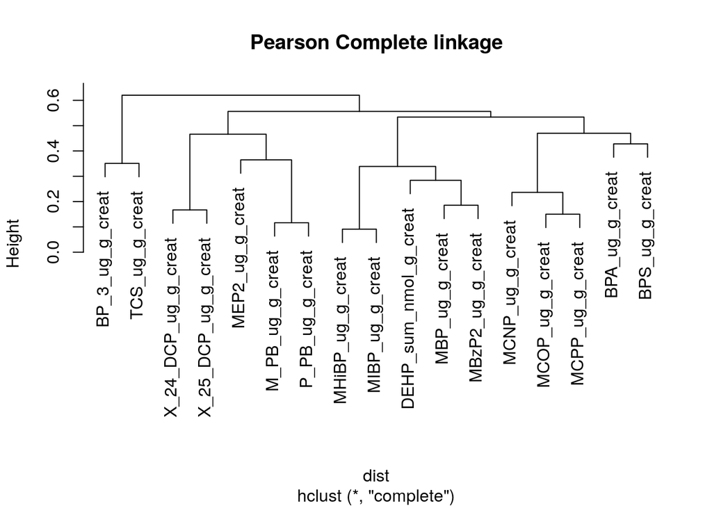

```r
hc <- my_h_clust(dist, "single", "Pearson Single linkage")
```

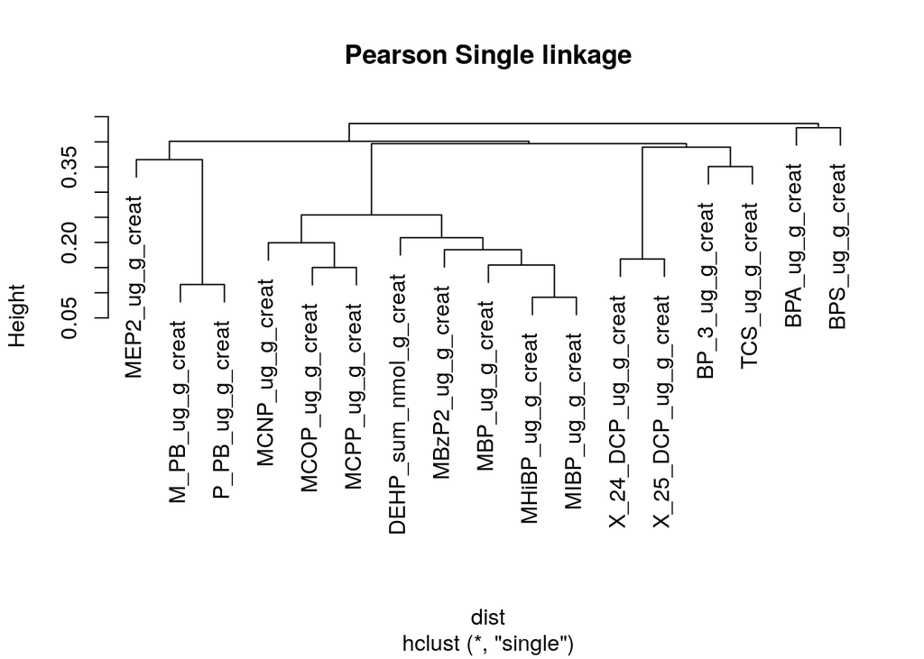

```r
hc <- my_h_clust(dist, "centroid", "Pearson Centroid linkage")
```

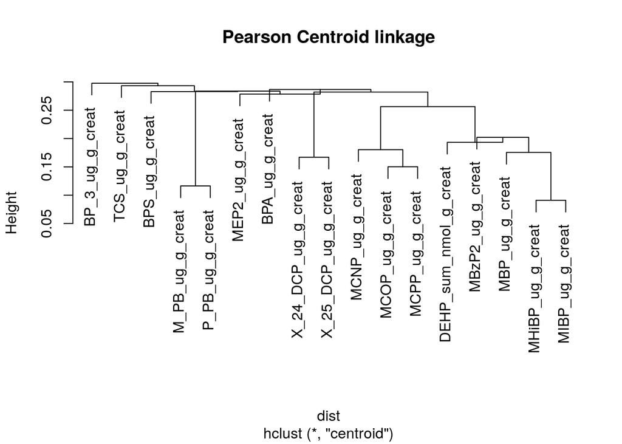

```r
# euclidean distance

dist <- dist(t(chems_log %>% rescale0_1()), method = "euclidean")
hc <- my_h_clust(dist, "complete", "Euclidean Complete linkage")
```

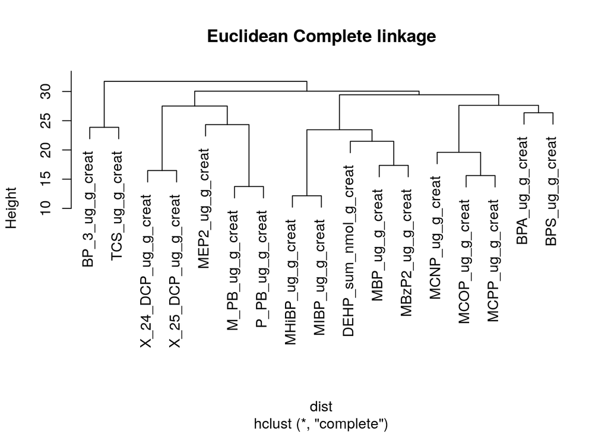

```r
hc <- my_h_clust(dist, "single", "Euclidean Single linkage")
```

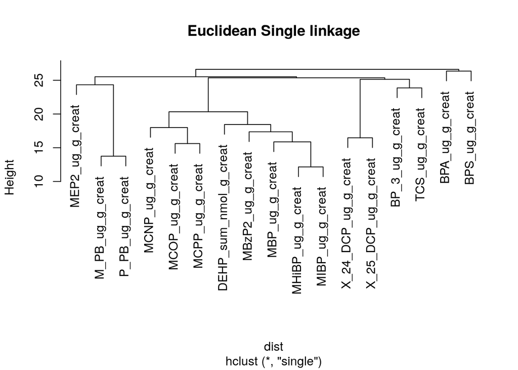

```r
hc <- my_h_clust(dist, "centroid", "Euclidean Centroid linkage")
```

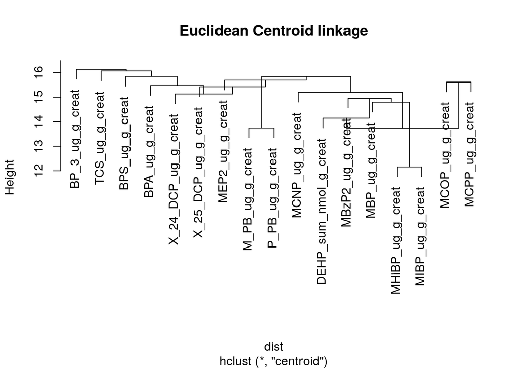

```r
dist <- dist(t(chems_log), method = "euclidean")
hc <- my_h_clust(dist, "complete", "Euclidean Centroid linkage")
```

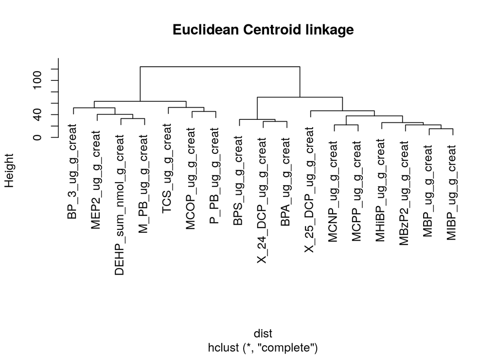

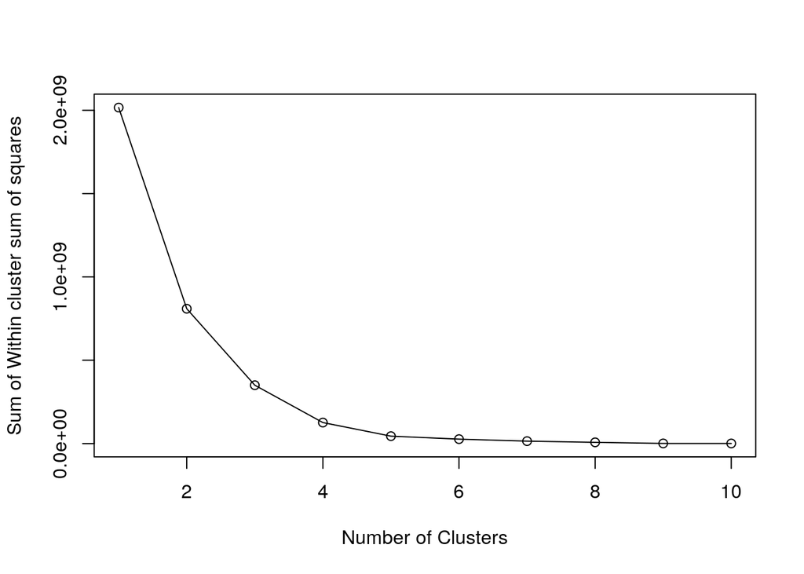

```r
########## k means clustering ############## kmeans cluster

## kmeans and try k
elbow_kmeans(t(chems), maxk = 10, iter.max = 10)
```

```r
km <- kmeans(t(chems), 4, iter.max = 10)
km$cluster
```

```
##      MHiBP_ug_g_creat        MBP_ug_g_creat      MBzP2_ug_g_creat
##                     1                     1                     1
##       MCNP_ug_g_creat       MCOP_ug_g_creat       MCPP_ug_g_creat
##                     1                     1                     1
##       MEP2_ug_g_creat       MIBP_ug_g_creat DEHP_sum_nmol_g_creat
##                     4                     1                     1
##   X_24_DCP_ug_g_creat   X_25_DCP_ug_g_creat       M_PB_ug_g_creat
##                     1                     2                     1
##       P_PB_ug_g_creat       BP_3_ug_g_creat        BPA_ug_g_creat
##                     1                     3                     1
##        BPS_ug_g_creat        TCS_ug_g_creat
##                     1                     1
```

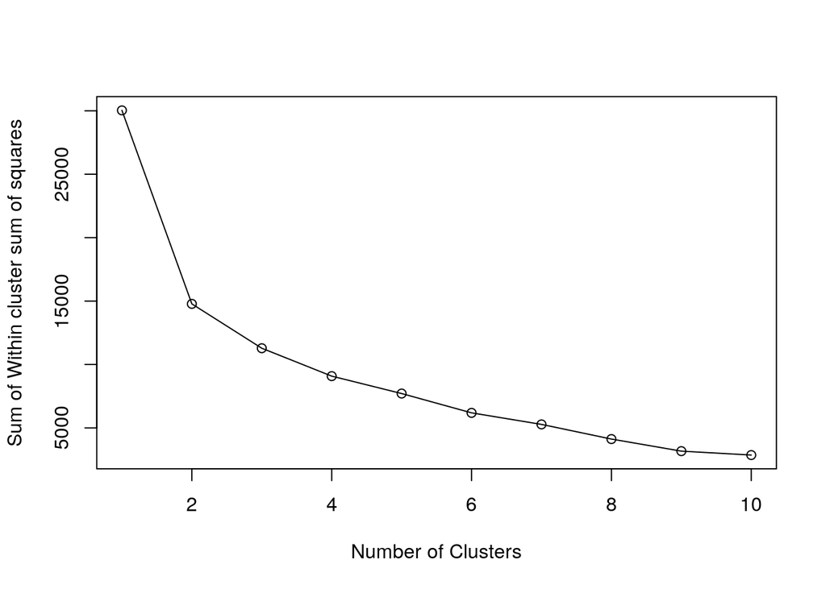

```r
elbow_kmeans(t(chems_log), maxk = 10, iter.max = 10)
```

```r
km <- kmeans(t(chems_log), 5, iter.max = 10)
km$cluster
```

```
##      MHiBP_ug_g_creat        MBP_ug_g_creat      MBzP2_ug_g_creat
##                     3                     3                     3
##       MCNP_ug_g_creat       MCOP_ug_g_creat       MCPP_ug_g_creat
##                     3                     1                     3
##       MEP2_ug_g_creat       MIBP_ug_g_creat DEHP_sum_nmol_g_creat
##                     1                     3                     4
##   X_24_DCP_ug_g_creat   X_25_DCP_ug_g_creat       M_PB_ug_g_creat
##                     5                     3                     4
##       P_PB_ug_g_creat       BP_3_ug_g_creat        BPA_ug_g_creat
##                     1                     4                     5
##        BPS_ug_g_creat        TCS_ug_g_creat
##                     5                     2
```

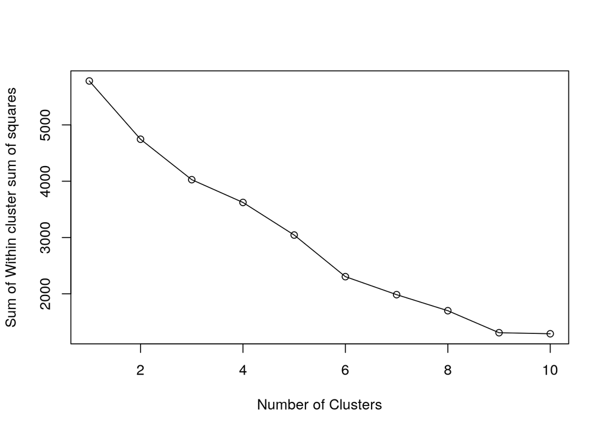

```r
elbow_kmeans(t(chems_log %>% rescale0_1()), maxk = 10, iter.max = 10)
```

```r
km <- kmeans(t(chems_log %>% rescale0_1()), 6, iter.max = 10)
km$cluster
```

```
##      MHiBP_ug_g_creat        MBP_ug_g_creat      MBzP2_ug_g_creat
##                     4                     4                     4
##       MCNP_ug_g_creat       MCOP_ug_g_creat       MCPP_ug_g_creat
##                     1                     1                     1
##       MEP2_ug_g_creat       MIBP_ug_g_creat DEHP_sum_nmol_g_creat
##                     6                     4                     4
##   X_24_DCP_ug_g_creat   X_25_DCP_ug_g_creat       M_PB_ug_g_creat
##                     5                     5                     3
##       P_PB_ug_g_creat       BP_3_ug_g_creat        BPA_ug_g_creat
##                     3                     3                     2
##        BPS_ug_g_creat        TCS_ug_g_creat
##                     2                     3
```

## 2.3 PCA

Robust PCA for skewed data and its outlier map: The outlier sensitivity of classical principal component analysis (PCA) has spurred the development of robust techniques.  
PCA analysis by prcomp() is preferred over princomp() for numerical accuracy (difference in calculating the variance).  
The data can be centered and scaled by the prcomp() function itself. The data is always z-score standardized for PCA analysis in my work.

## 2.4 Factor analysis

Factor analysis is a statistical method used to describe variability among observed, correlated variables in terms of a potentially lower number of unobserved variables called factors. For example, it is possible that variations in six observed variables mainly reflect the variations in two unobserved (underlying) variables. Factor analysis searches for such joint variations in response to unobserved latent variables. The observed variables are modelled as linear combinations of the potential factors, plus “error” terms. Factor analysis aims to find independent latent variables.  
1. Exploratory factor analysis (EFA) is used to identify complex interrelationships among items and group items that are part of unified concepts.  
2. Confirmatory factor analysis (CFA) is a more complex approach that tests the hypothesis that the items are associated with specific factors.  
Principal component analysis (PCA) is a widely used method for factor extraction, which is the first phase of EFA.

```r
###### pca ########
source( paste0(dir, "Code/more_chems/Dimen_reduc_clustering.R") )
# the log transformation is necessary
pca_chems <- wrapper_prcomp(chems)
```

```
## [1] "Using prcomp, standard observation, variable data frame"
```

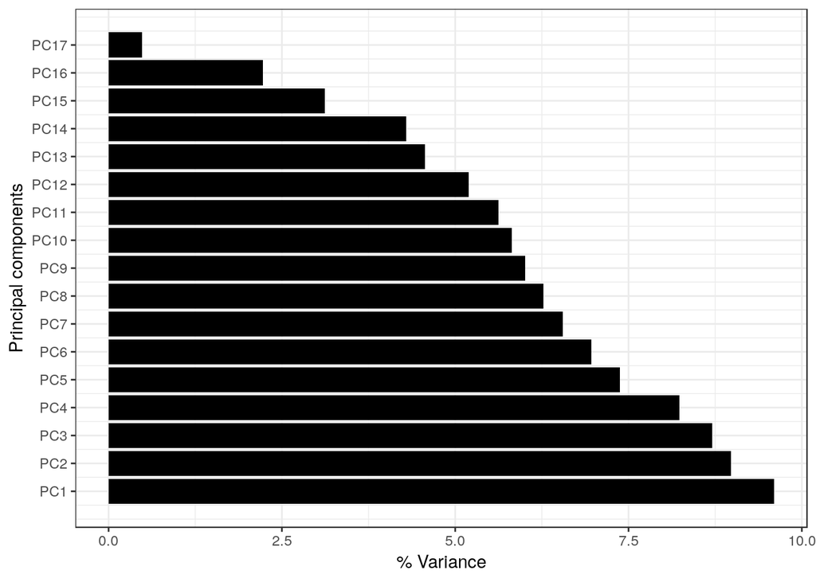

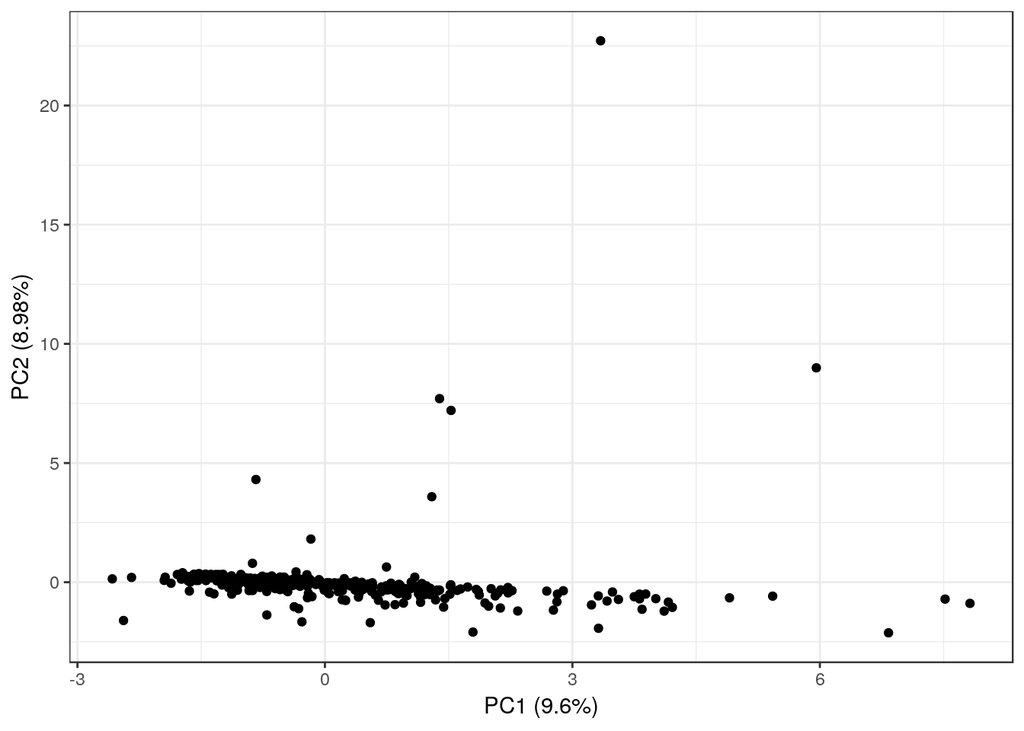

```r
pca_chems_log <-wrapper_prcomp(chems_log)
```

```
## [1] "Using prcomp, standard observation, variable data frame"
```

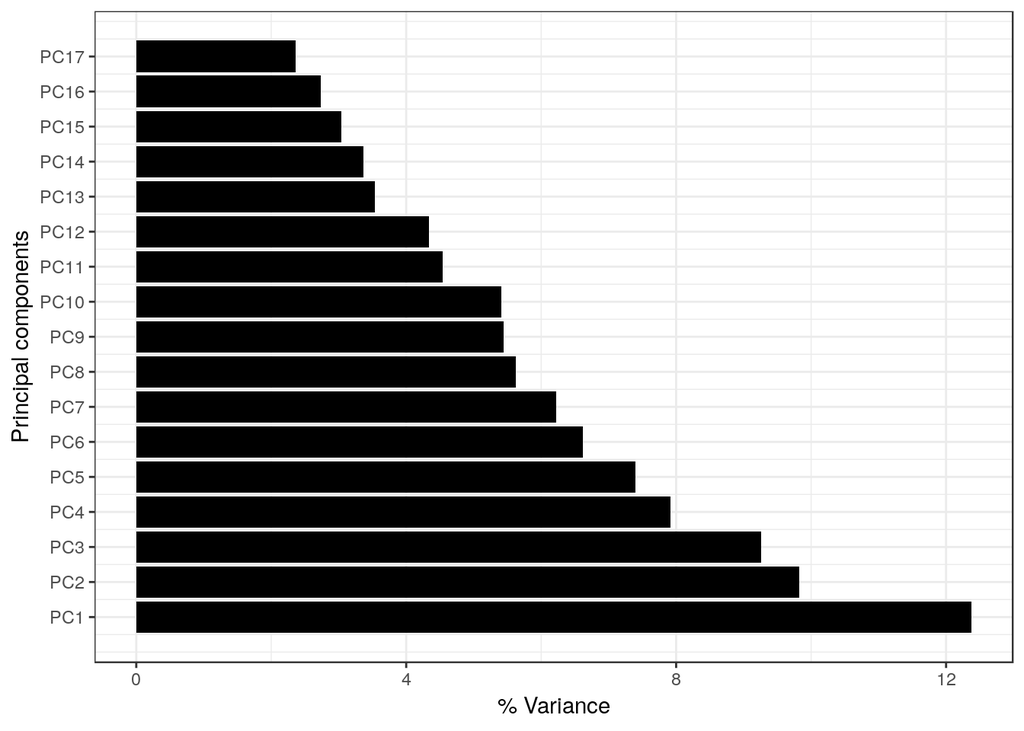

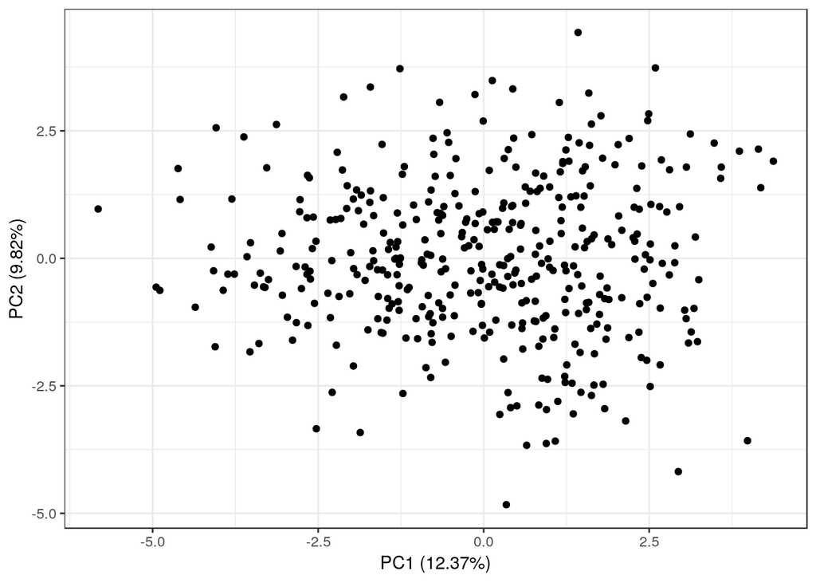

```r
## preliminary factor analysis ##
n.factors <- 5

fit <- factanal(chems_log,
                n.factors,                # number of factors to extract
                scores=c("regression"),
                rotation="none")

print(fit, digits=4, cutoff=.3, sort=TRUE)
```

```
##
## Call:
## factanal(x = chems_log, factors = n.factors, scores = c("regression"),     rotation = "none")
##
## Uniquenesses:
##      MHiBP_ug_g_creat        MBP_ug_g_creat      MBzP2_ug_g_creat
##                0.2943                0.4404                0.7008
##       MCNP_ug_g_creat       MCOP_ug_g_creat       MCPP_ug_g_creat
##                0.5327                0.3263                0.2924
##       MEP2_ug_g_creat       MIBP_ug_g_creat DEHP_sum_nmol_g_creat
##                0.8620                0.0622                0.5143
##   X_24_DCP_ug_g_creat   X_25_DCP_ug_g_creat       M_PB_ug_g_creat
##                0.0050                0.2427                0.2076
##       P_PB_ug_g_creat       BP_3_ug_g_creat        BPA_ug_g_creat
##                0.2562                0.8219                0.9738
##        BPS_ug_g_creat        TCS_ug_g_creat
##                0.9538                0.4645
##
## Loadings:
##                       Factor1 Factor2 Factor3 Factor4 Factor5
## MHiBP_ug_g_creat       0.8165
## MBP_ug_g_creat         0.7321
## MBzP2_ug_g_creat       0.5249
## MIBP_ug_g_creat        0.9608
## DEHP_sum_nmol_g_creat  0.5568  0.3875
## MCNP_ug_g_creat                0.6191
## MCOP_ug_g_creat                0.7419
## MCPP_ug_g_creat                0.7358
## M_PB_ug_g_creat                        0.8353
## P_PB_ug_g_creat                        0.8201
## X_24_DCP_ug_g_creat                            0.9974
## X_25_DCP_ug_g_creat                            0.6718  0.5193
## TCS_ug_g_creat                                        -0.6633
## MEP2_ug_g_creat                        0.3010
## BP_3_ug_g_creat                                       -0.3514
## BPA_ug_g_creat
## BPS_ug_g_creat
##
##                Factor1 Factor2 Factor3 Factor4 Factor5
## SS loadings     2.9525  1.8660  1.7279  1.5648  0.9380
## Proportion Var  0.1737  0.1098  0.1016  0.0920  0.0552
## Cumulative Var  0.1737  0.2834  0.3851  0.4771  0.5323
##
## Test of the hypothesis that 5 factors are sufficient.
## The chi square statistic is 245.64 on 61 degrees of freedom.
## The p-value is 5.35e-24
```

# 3 Questions

1. We also will include BPA, and mono (carboxynonyl) phthalate (MCNP), perfluorooctane sulfonic acid (PFOS), 2-(N-methyl-PFOSA) acetic acid, and perfluorodecanoic acid in our measurements to evaluate them as possible confounders. Based on the question of interests, clustering of chemicals?